# Getting data into and ready for the tidyverse

# Getting things right from the beginning

If you want to have a good time in R, it’s sensible to get things right from the beginning - to structure your work/data in a way that’s as easy as possible to work with.

Many users of R begin their work with:

```r
setwd("/Users/martinjhnhadley/GoogleDrive/courses/interactive-stat-viz")
```

This is a bad way to start.

# Make your code as transportable as possible

Explicitly setting working directories makes it difficult for others to run your code, particularly if they are running a different operating system.

Thankfully, RStudio has a great feature called “projects” which handle setting your working directory for you.

# RStudio projects

Projects provide a useful mechanic for clearly distinguishing between different work packages/projects. Working with projects provides the following advantages:

- Working directories are set as the project directory
- The project directory can easily be explored through a GUI
- Easily switch between Projects from the Project menu.

# Creating RStudio projects

Whenever you start a new project at work, start a new project in RStudio.

1. File -> New Project OR the Projects menu in the top-right of the screen

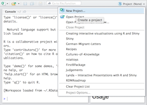

2. Choose “New Directory” and “Empty Project”
3. Browse to where your R projects will live
4. Give your project a sensible name, like “wrangling-tutorial”

# Organising your data

Well organised projects have two data folders:

- data-raw/ which contains your raw, messy, and non-anonymised data. It should also contain scripts for cleaning and tidying your data, the outputs of which should be written into the data folder
- data which contains the version of your data you’re happy to share

Following this advice ensures you never accidentally your original data, because it’s read-only. Plus, your anonymisation process is now fully self-contained and easily removed before publication.

# Reproducability Everywhere

Making your own lives easier when working in R is only a good thing and you’re helping others for free!

There are lots of bad practices people pick up and never invest enough time in considering the benefits of fixing.

One of these in the naming of files (particularly data files), and I’d like to refer you to these excellent slides from @JennyBryan:

https://speakerdeck.com/jennybc/how-to-name-files

# Reading csvs and tidying them up

In the handouts folder you’ll find a folder called “wrangling-tutorial”, let’s turn that into a project together that we can start working with.

# Example datasets

Many tutorials make use of very small, simple datasets like the following:

```r
knitr::kable(head(mtcars))
```

|  | mpg | cyl | disp | hp | drat | wt | qsec | vs | am | gear | carb |
| --- | --- | --- | --- | --- | --- | --- | --- | --- | --- | --- | --- |
| Mazda RX4 | 21.0 | 6 | 160 | 110 | 3.90 | 2.620 | 16.46 | 0 | 1 | 4 | 4 |
| Mazda RX4 Wag | 21.0 | 6 | 160 | 110 | 3.90 | 2.875 | 17.02 | 0 | 1 | 4 | 4 |
| Datsun 710 | 22.8 | 4 | 108 | 93 | 3.85 | 2.320 | 18.61 | 1 | 1 | 4 | 1 |
| Hornet 4 Drive | 21.4 | 6 | 258 | 110 | 3.08 | 3.215 | 19.44 | 1 | 0 | 3 | 1 |
| Hornet Sportabout | 18.7 | 8 | 360 | 175 | 3.15 | 3.440 | 17.02 | 0 | 0 | 3 | 2 |
| Valiant | 18.1 | 6 | 225 | 105 | 2.76 | 3.460 | 20.22 | 1 | 0 | 3 | 1 |

> Simple datasets are fine, but they are radically different from the data that you find in the real world.

> Real data is messy, incomplete and inconsistent. I feel it’s really important to work with real datasets where possible.

# Our dataset

Through the next few activities and topics we’ll be using a dataset that is loosely based on my work with Felix Krawatzek that he wrote about here:

https://theconversation.com/writing-home-how-german-immigrants-found-their-place-in-the-us-53342

The actual underlying data is unpublished as of August 2017 but will be made available here: https://doi.org/10.6084/m9.figshare.4516772

# Getting a feel for a data

Let’s create a data-clean.R file in the /data-raw folder and use this to build an understanding of what our data looks like - and create a cleaner version of the data to eventually export into the /data folder.

# Importing the data using tidyverse

Flat files like our journeys.csv file are imported into R using the readr library - part of the core tidyverse.

To import our file we can simply write:

```r
library("tidyverse")

journeys <- read_csv("data-raw/journeys.csv")
```

readr is extremely helpful and prints us a summary of how it’s intepreted each of our columns in the console.

# Splitting locations into country and city

The start.location and end.location columns contain (at least) two pieces of information:

- Country
- City
- State

We’re going to use the dplyr library to split these columns up with the *separate* verb.

# Separate pipe chain

Tidyverse operations are almost always written as a sequence of pipes:

```r
journeys %>%
  separate(start.location, into = c("start.country", "start.city"))
```

# What is %>%?

The %>% [pipe operator] is an intrinsic part of the tidyverse and pretty much every single htmlwidget library is designed with them in mind.

For an example of why we want to use pipes, I’ll borrow the [following example](https://twitter.com/AmeliaMN/status/748193609401327616) from Hadley Wickham:

> Little bunny Foo Foo  
> Went hopping through the forest  
> Scooping up the field mice  
> And bopping them on the head

```r
foo_foo <- little_bunny()
```

```r
bop_on(
  scoop_up(
    hop_through(foo_foo, forest),
    field_mouse
  ),
  head
)
```

```r
foo_foo %>%
  hop_through(forest) %>%
  scoop_up(field_mouse) %>%
  bop_on(head)
```

# Simpler %>% example

The pipe operator takes the left-hand side of your expression and inserts it into the first argument of the right-hand side of the expression:

```r
"cats" %>% rep(4)
```

In some cases you don’t want the left-hand side in the first argument, you can explicitly shove it somewhere else by using a period

```r
"cats" %>% paste("too","many", .)
```

The `%>%` operator comes from the `magrittr` library and can be read about more [here](http://magrittr.tidyverse.org/). While it is often incredibly useful, it is not a hammer to be used without exception - some code is both harder to write and code with pipes.

Also - you’re allowed to hate pipes. That’s fine.

# Back to separating columns

```r
journeys %>%
  separate(start.location, into = c("start.country", "start.city"))
```

# Counting observations

Now we’ve split the start.location column up, we can start to summarise and understand our data.

If we simply wanted to count the number of observations in each unique country, we could do the following:

```r
journeys %>%
  count(start.country)
```

# Grouping data

Count is only useful for tallying observations, to categorically summarise your data more flexibly you should use the group_by verb:

```r
journeys %>%
  group_by(start.country)
```

We can then add new columns that calculate values within these groups using two different verbs:

- mutate
- summarise

# The universe of verbs

The tidyverse has a vast array of very powerful verbs, we’re using a tiny subset of them here.

To learn more I’ll re-recommend the resources I’ve mentioned previously:

- r4ds.had.co.nz: Online version of R for Data Science by Garrett Grolemund & Hadley Wickham
- [RStudio Cheats Sheets](https://www.rstudio.com/resources/cheatsheets/): Excellent, printable (!) resources which are also baked into RStudio (Help -> Cheatsheets)

# Cleaning up and exporting

Let’s not get further distracted with the cleaning of this data, I’ve provided a script that finishes tidying up this dataset for visualisation:

RSS_handouts/export-code